# Reproducible Research : Peer assesment 1

Alexis de la Cotte

2/27/2021

# Step 1: Load the data

```r
data <- read.csv(file = 'activity.csv')
summary(data)
```

```
##      steps            date              interval
##  Min.   :  0.00   Length:17568       Min.   :   0.0
##  1st Qu.:  0.00   Class :character   1st Qu.: 588.8
##  Median :  0.00   Mode  :character   Median :1177.5
##  Mean   : 37.38                      Mean   :1177.5
##  3rd Qu.: 12.00                      3rd Qu.:1766.2
##  Max.   :806.00                      Max.   :2355.0
##  NA's   :2304
```

As can be seen above, the dataset contains 3 columns:

- steps: number of steps taken in a 5min interval
- date: the date in YYYY-MM-DD format
- interval: the identifier of the 5min interval

Right now the date column is still considered as ‘character’ type, so lets convert it to be an actual date:

```r
data$date <- as.Date(data$date)
summary(data)
```

```
##      steps             date               interval
##  Min.   :  0.00   Min.   :2012-10-01   Min.   :   0.0
##  1st Qu.:  0.00   1st Qu.:2012-10-16   1st Qu.: 588.8
##  Median :  0.00   Median :2012-10-31   Median :1177.5
##  Mean   : 37.38   Mean   :2012-10-31   Mean   :1177.5
##  3rd Qu.: 12.00   3rd Qu.:2012-11-15   3rd Qu.:1766.2
##  Max.   :806.00   Max.   :2012-11-30   Max.   :2355.0
##  NA's   :2304
```

Also the interval should correspond to an hour format, so let’s convert it as well:

```r
data$interval <- sub("([0-9]{2})([0-9]{2})", "\\1:\\2",sprintf('%04d',data$interval))
summary(data)
```

```
##      steps             date              interval
##  Min.   :  0.00   Min.   :2012-10-01   Length:17568
##  1st Qu.:  0.00   1st Qu.:2012-10-16   Class :character
##  Median :  0.00   Median :2012-10-31   Mode  :character
##  Mean   : 37.38   Mean   :2012-10-31
##  3rd Qu.: 12.00   3rd Qu.:2012-11-15
##  Max.   :806.00   Max.   :2012-11-30
##  NA's   :2304
```

# Step 2: Histogram of total number of steps taken each day

First we want to group the data by day and get the sum:

```r
data_step_day <- tapply(data$steps,data$date,FUN = sum, na.rm = TRUE)
summary(data_step_day)
```

```
##    Min. 1st Qu.  Median    Mean 3rd Qu.    Max.
##       0    6778   10395    9354   12811   21194
```

The distribution has a mean of 9354 and a median of 10395.

We can then look at a histogram of the distribution:

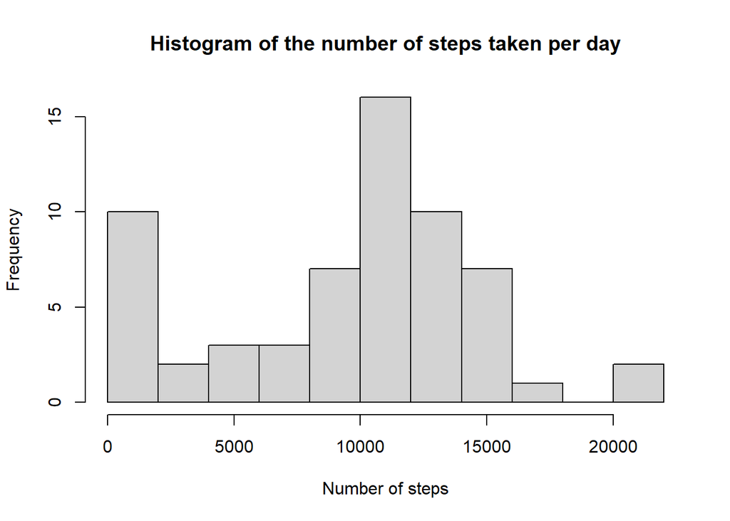

```r
hist(data_step_day,breaks = 10, main = 'Histogram of the number of steps taken per day', xlab = 'Number of steps', ylab = 'Frequency')
```

There is quite a large number of days where a few number of steps were taken. This is probably due to the presence of “NA”s in the data frame, we will correct for this in step 4.

# Step 3: Mean average number of step time series

We want to look for the span of 24h, what is the average number of steps taken in each of the 5min interval. First we want to group the data by interval:

```r
data_avstep_interval <- tapply(data$steps, data$interval, FUN = mean, na.rm = TRUE)
summary(data_avstep_interval)
```

```
##    Min. 1st Qu.  Median    Mean 3rd Qu.    Max.
##   0.000   2.486  34.113  37.383  52.835 206.170
```

The maximum average steps taken is 206 for the 5min interval starting at 08:35.

We can also look now at the time series of the average number of steps:

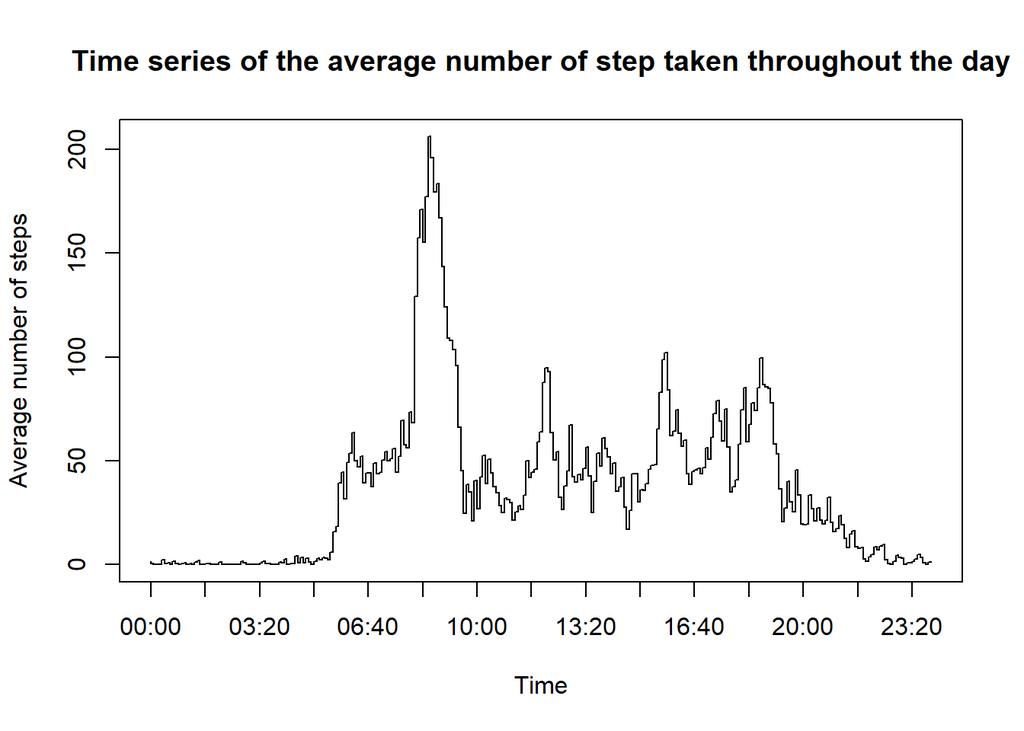

```r
plot(data_avstep_interval, type = "S", main = 'Time series of the average number of step taken throughout the day', ylab = 'Average number of steps', xlab = 'Time', xaxt = 'n')
axis(1,at = seq(1,length(data_avstep_interval),20) , labels = names(data_avstep_interval[(seq(1,length(data_avstep_interval),20))]))
```

# Step 4: Inputing missing data

Some rows in the original data is “NA”, and it would be good to replace these with some actual numbers. The best strategy, I believe, is to replace them by the rounded average of the given time interval.

```r
for(row in 1:nrow(data)){

      if(is.na(data[row,]$steps)){

         data[row,]$steps = round(data_avstep_interval[data[row,]$interval])

      }


}

summary(data)
```

```
##      steps             date              interval
##  Min.   :  0.00   Min.   :2012-10-01   Length:17568
##  1st Qu.:  0.00   1st Qu.:2012-10-16   Class :character
##  Median :  0.00   Median :2012-10-31   Mode  :character
##  Mean   : 37.38   Mean   :2012-10-31
##  3rd Qu.: 27.00   3rd Qu.:2012-11-15
##  Max.   :806.00   Max.   :2012-11-30
```

As we can be seen in the summary of the dataset, there is no “NA”s anymore in the dataframe. We can then look again at a histogram of the total number of steps taken per day:

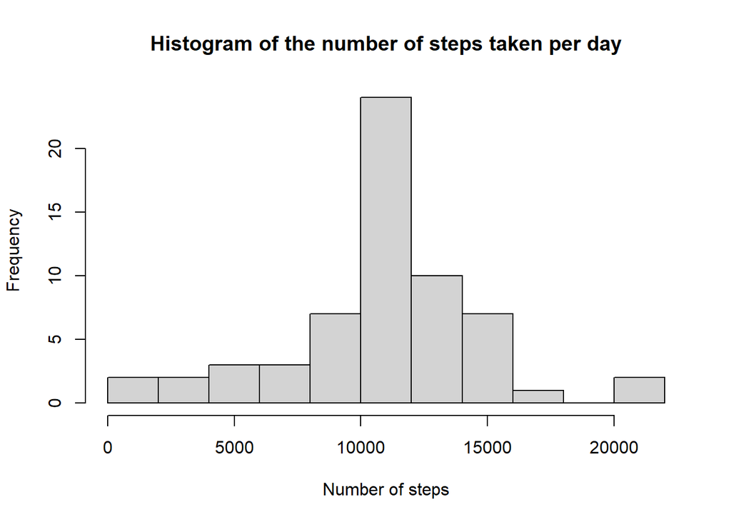

```r
data_step_day <- tapply(data$steps,data$date,FUN = sum, na.rm = TRUE)
hist(data_step_day,breaks = 10, main = 'Histogram of the number of steps taken per day', xlab = 'Number of steps', ylab = 'Frequency')
```

We can see the correction works, the large number of days with a low number of steps taken has fallen.

The new distribution has a mean of 10766 and a median of 10762.

# Step 5: Compare average step taken, weekdays vs weekend

First we want to add a week day column in the dataframe:

```r
data$weekday <- weekdays(data$date)
head(data)
```

```
##   steps       date interval weekday
## 1     2 2012-10-01    00:00  Monday
## 2     0 2012-10-01    00:05  Monday
## 3     0 2012-10-01    00:10  Monday
## 4     0 2012-10-01    00:15  Monday
## 5     0 2012-10-01    00:20  Monday
## 6     2 2012-10-01    00:25  Monday
```

Then we can create two dataframes one for the week days, one for the weekend:

```r
data_weekend <- subset(data, data$weekday == "Sunday" | data$weekday == "Saturday")
data_weekdays <- subset(data, data$weekday != "Sunday" & data$weekday != "Saturday")

head(data_weekdays)
```

```
##   steps       date interval weekday
## 1     2 2012-10-01    00:00  Monday
## 2     0 2012-10-01    00:05  Monday
## 3     0 2012-10-01    00:10  Monday
## 4     0 2012-10-01    00:15  Monday
## 5     0 2012-10-01    00:20  Monday
## 6     2 2012-10-01    00:25  Monday
```

```r
head(data_weekend)
```

```
##      steps       date interval  weekday
## 1441     0 2012-10-06    00:00 Saturday
## 1442     0 2012-10-06    00:05 Saturday
## 1443     0 2012-10-06    00:10 Saturday
## 1444     0 2012-10-06    00:15 Saturday
## 1445     0 2012-10-06    00:20 Saturday
## 1446     0 2012-10-06    00:25 Saturday
```

We can then get the average number of steps taken for each 5min time interval, segregated by weekdays and weekend.

```r
data_avstep_interval_weekend <- tapply(data_weekend$steps, data_weekend$interval, FUN = mean)
summary(data_avstep_interval_weekend)
```

```
##    Min. 1st Qu.  Median    Mean 3rd Qu.    Max.
##   0.000   1.234  32.312  42.365  74.609 166.625
```

```r
data_avstep_interval_weekdays <- tapply(data_weekdays$steps, data_weekdays$interval, FUN = mean, na.rm = TRUE)
summary(data_avstep_interval_weekdays)
```

```
##    Min. 1st Qu.  Median    Mean 3rd Qu.    Max.
##   0.000   2.289  25.811  35.609  50.806 230.356
```

We can now plot a side by side comparison of the time series of the average number of steps taken, weekend vs weekdays:

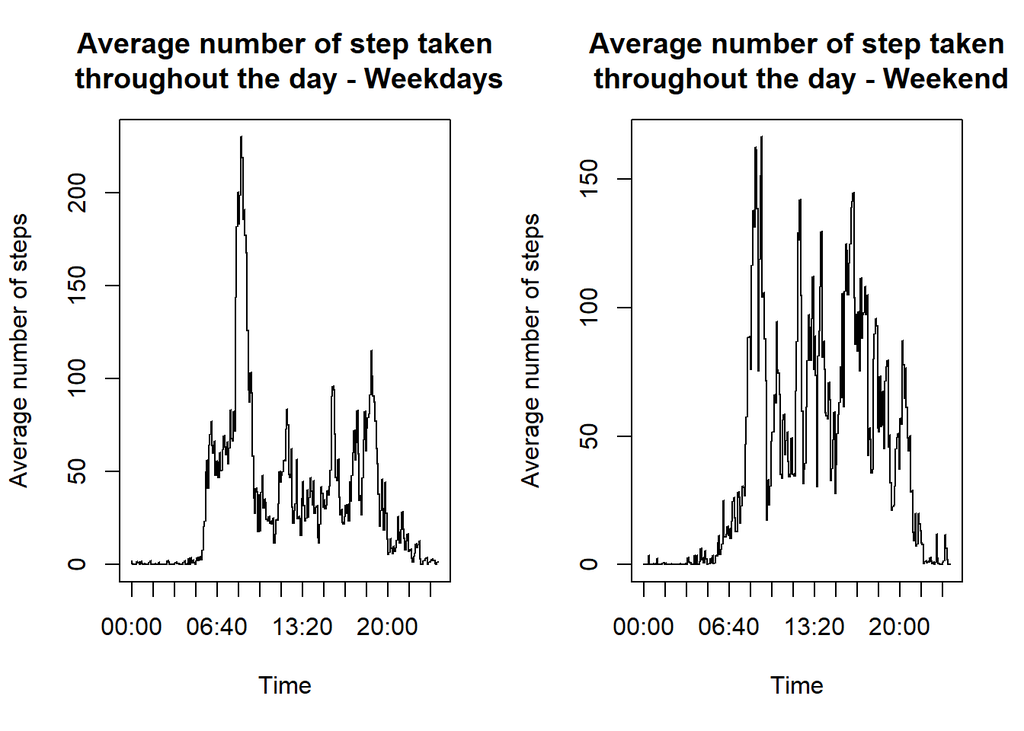

```r
par(mfrow = c(1,2))

plot(data_avstep_interval_weekdays, type = "S", main = 'Average number of step taken\n throughout the day - Weekdays', ylab = 'Average number of steps', xlab = 'Time', xaxt = 'n')
axis(1,at = seq(1,length(data_avstep_interval_weekdays),20) , labels = names(data_avstep_interval[(seq(1,length(data_avstep_interval_weekdays),20))]))

plot(data_avstep_interval_weekend, type = "S", main = 'Average number of step taken\n throughout the day - Weekend', ylab = 'Average number of steps', xlab = 'Time', xaxt = 'n')
axis(1,at = seq(1,length(data_avstep_interval_weekend),20) , labels = names(data_avstep_interval[(seq(1,length(data_avstep_interval_weekend),20))]))
```

We can see that the activity picks-up earlier during weekdays than the weekend. But the activity then remains quite high during the weekend until the end of the day, when it drops in the weekdays during the working hours.